# My Website

Hello! Welcome to the world.

Hello, my name is Caitlin Shanahan. I am a second year Masters student at UNH and member of Dr. Fairchild’s lab. Originally from Maryland, I received my B.S. in Marine Biology from Roger Williams University in May 2017. In spring 2018, I moved to Fort Lauderdale, Florida to work for Broward County Sea Turtle Conservation Program as a sea turtle specialist. While a member of that program, I worked under a PhD student to help collect samples from and tag (flipper, PIT, and satellite) nesting loggerhead and green sea turtles. I also volunteered for Guy Harvey’s Research Institute tagging and collecting samples of the shark population off of south Florida’s coastline. I will forever cherish my time and the people that I met in Florida due to this job.

Since moving to New Hampshire to attend UNH, I have fallen back in love with being outdoors. It turns out that when it is not the temperature of HELL outside, I quite love spending my time outside of the AC. My boyfriend, Mark, and I have taken to hiking weekly. At the moment we are trying to conquer NH’s “52 with a View”. It is a collection of 52 mountains that have great views. If anything it is just a list with ideas for good hikes. Our pup, Kona, loves hiking probably more than either of us. I have included a picture of Kona and I at the top of one of the 52. He is wearing his little hiking pack - carrying his own water and food to the top cause it slows his pace just a bit. When the snow comes in just a few weeks, I will switch out my hiking boots for ski boots and slide down the mountains rather than hiking them. UNH is a great school and I am excited about my project, but NH offers so many (more fun) outdoor activities that are more exciting alternatives to struggling with R. Here’s to finding motivation!

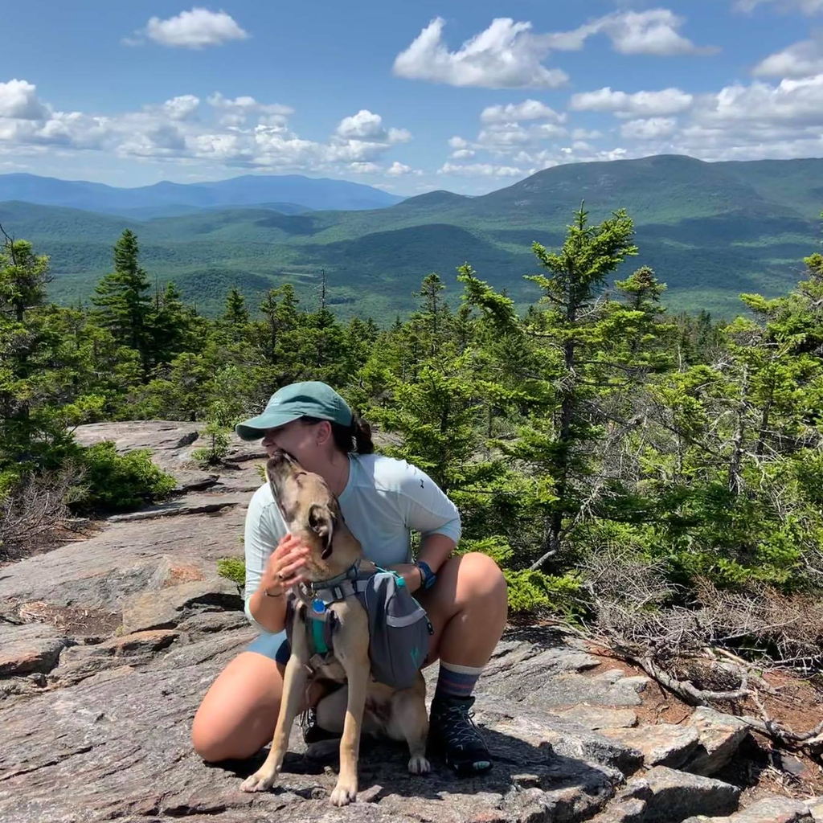

Kona is the hiking master